# Final Project

Ashley L. Miller

1/28/2019

The purpose of this post is to demonstrate various methods of visualizing uncertainty, particuarily with pupillometry data.

The dataset I will be using for this demonstation is de-identified and already hosted on Github. The data come from one of my recent publications (Experiment 1; [Miller, Gross, & Unsworth, 2019](https://www.sciencedirect.com/science/article/pii/S0749596X18300846)). In this paper, pupil dilation was used as an index of the intensity of attention to determine if variation in attention at encoding partially accounts for the relation between working memory capacity (WMC) and long-term memory performance (LTM). Participants (*N* = 138) completed a battery of complex span working memory tasks, followed by a delayed free recall task while pupil dilation was simultaneously recorded.

Let’s load and inspect the data:

```r
data <- import(here("data", "DeIntentifiedJML2019Data_Exp1.sav"),
               setclass = "tibble") %>%
  characterize() %>%
  janitor::clean_names()

head(data)
```

```
## # A tibble: 6 x 183
##   subject sp1_acc sp2_acc sp3_acc sp4_acc sp5_acc sp6_acc sp7_acc sp8_acc
##     <dbl>   <dbl>   <dbl>   <dbl>   <dbl>   <dbl>   <dbl>   <dbl>   <dbl>
## 1       1     1       0.8     1       1       0.8     1       0.2     0.4
## 2       2     0.6     0.4     1       0.8     0.8     0.6     0.8     0.6
## 3       3     1       1       0.4     0.6     0       0.8     0.4     0.4
## 4       4     1       1       0.8     0.8     0.4     0.6     0.2     0.6
## 5       5     0.8     1       0.6     0.4     0.6     0.4     0.4     0.2
## 6       6     1       0.8     0.6     0.6     0.2     0.2     0.4     0
## # … with 174 more variables: sp9_acc <dbl>, sp10_acc <dbl>,
## #   passive_read_strat <dbl>, rehearsal_strat <dbl>,
## #   sentence_gen_strat <dbl>, imagery_strat <dbl>, grouping_strat <dbl>,
## #   other_strat <dbl>, accuracy_mean <dbl>, ospan <dbl>, rspan <dbl>,
## #   symspan <dbl>, wmc <dbl>, span_group <chr>, ineffective <dbl>,
## #   effective <dbl>, primacy_recall <dbl>, middle_recall <dbl>,
## #   recency_recall <dbl>, baseline_pupil_mean <dbl>, tepr_mean <dbl>,
## #   tepr_primacy <dbl>, tepr_mid <dbl>, tepr_recency <dbl>,
## #   ebin1w1pt4_mean <dbl>, ebin2w1pt4_mean <dbl>, ebin3w1pt4_mean <dbl>,
## #   ebin4w1pt4_mean <dbl>, ebin5w1pt4_mean <dbl>, ebin6w1pt4_mean <dbl>,
## #   ebin7w1pt4_mean <dbl>, ebin8w1pt4_mean <dbl>, ebin9w1pt4_mean <dbl>,
## #   ebin10w1pt4_mean <dbl>, ebin11w1pt4_mean <dbl>,
## #   ebin12w1pt4_mean <dbl>, ebin13w1pt4_mean <dbl>,
## #   ebin14w1pt4_mean <dbl>, ebin15w1pt4_mean <dbl>, ebin1w2pt4_mean <dbl>,
## #   ebin2w2pt4_mean <dbl>, ebin3w2pt4_mean <dbl>, ebin4w2pt4_mean <dbl>,
## #   ebin5w2pt4_mean <dbl>, ebin6w2pt4_mean <dbl>, ebin7w2pt4_mean <dbl>,
## #   ebin8w2pt4_mean <dbl>, ebin9w2pt4_mean <dbl>, ebin10w2pt4_mean <dbl>,
## #   ebin11w2pt4_mean <dbl>, ebin12w2pt4_mean <dbl>,
## #   ebin13w2pt4_mean <dbl>, ebin14w2pt4_mean <dbl>,
## #   ebin15w2pt4_mean <dbl>, ebin1w3pt4_mean <dbl>, ebin2w3pt4_mean <dbl>,
## #   ebin3w3pt4_mean <dbl>, ebin4w3pt4_mean <dbl>, ebin5w3pt4_mean <dbl>,
## #   ebin6w3pt4_mean <dbl>, ebin7w3pt4_mean <dbl>, ebin8w3pt4_mean <dbl>,
## #   ebin9w3pt4_mean <dbl>, ebin10w3pt4_mean <dbl>, ebin11w3pt4_mean <dbl>,
## #   ebin12w3pt4_mean <dbl>, ebin13w3pt4_mean <dbl>,
## #   ebin14w3pt4_mean <dbl>, ebin15w3pt4_mean <dbl>, ebin1w4pt4_mean <dbl>,
## #   ebin2w4pt4_mean <dbl>, ebin3w4pt4_mean <dbl>, ebin4w4pt4_mean <dbl>,
## #   ebin5w4pt4_mean <dbl>, ebin6w4pt4_mean <dbl>, ebin7w4pt4_mean <dbl>,
## #   ebin8w4pt4_mean <dbl>, ebin9w4pt4_mean <dbl>, ebin10w4pt4_mean <dbl>,
## #   ebin11w4pt4_mean <dbl>, ebin12w4pt4_mean <dbl>,
## #   ebin13w4pt4_mean <dbl>, ebin14w4pt4_mean <dbl>,
## #   ebin15w4pt4_mean <dbl>, ebin1w5pt4_mean <dbl>, ebin2w5pt4_mean <dbl>,
## #   ebin3w5pt4_mean <dbl>, ebin4w5pt4_mean <dbl>, ebin5w5pt4_mean <dbl>,
## #   ebin6w5pt4_mean <dbl>, ebin7w5pt4_mean <dbl>, ebin8w5pt4_mean <dbl>,
## #   ebin9w5pt4_mean <dbl>, ebin10w5pt4_mean <dbl>, ebin11w5pt4_mean <dbl>,
## #   ebin12w5pt4_mean <dbl>, ebin13w5pt4_mean <dbl>,
## #   ebin14w5pt4_mean <dbl>, ebin15w5pt4_mean <dbl>, ebin1w6pt4_mean <dbl>,
## #   …
```

Now I will tidy the data a bit by selecting the key variables of interest then renaming the remaining variables:

```r
# Select variables of interest for pupil data
pupil_data <- data %>%
  select(-sp1_acc:-symspan,
         -ineffective:-recency_recall,
         -baseline_pupil_mean:-tepr_recency)

# Cam's efficient method to rename bin/word variables
# E.g., data currently reads ebin1w1pt4_mean
# I just want the variable to read bin1w1
pupil_data %<>%
  rename_at(
    vars(starts_with("ebin")),
    funs(
      paste(
        str_extract(., "w\\d{1,2}"),
        "_",
        str_extract(., "bin\\d{1,2}"),
        sep = "")))
```

### Plot 1

I first plot changes in pupil diameter across the 3 second study/encoding phase for each word (i.e., bin). As a starting point, see Fig. 4 in [Miller et al. (2019)](https://www.sciencedirect.com/science/article/pii/S0749596X18300846) below:

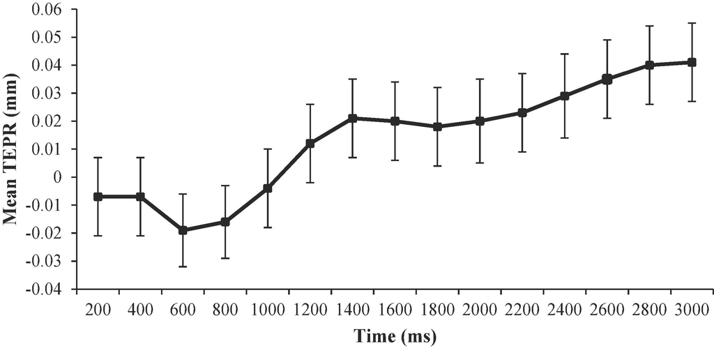

I intend to enhance this plot in a number of ways. But, namely, I want to map uncertaintly (previously shown with the standard error bars) via bootstrapping/generatation of outcome draws from a fitted model. For more details on this method, I highly recommend reading up on Claus O. Wilke’s [ungeviz package](https://wilkelab.org/ungeviz/articles/posterior-draws.html). Another good reference can be located [here](https://wilkelab.org/ungeviz/reference/bootstrapper.html).

The intended audience for this graph is the **scientific community**, but it is also my hope that interested layspersons may also be able to understand it. The intended message to be communicated is that when instructed to study a list of words, pupil diameter increases throughout the study phase for each word. This increase in pupil dilation is believed to reflect an increase in the amount of attentional effort devoted to a given item.

The code is as follows:

```r
# Tidy data:
plot1_data <- pupil_data %>%
  gather(key = word_bin, value = TEPR, w1_bin1:w10_bin15) %>%
  separate(word_bin, c("word", "bin"), sep = "_") %>%
  mutate(word = parse_number(word),
         bin = parse_number(bin)) %>%
  arrange(subject)

#glimpse(plot1_data)
```

```r
plot1 <- plot1_data %>%
  group_by(bin) %>%
  summarise(mean_TEPR = mean(TEPR, na.rm = TRUE),
            se_TEPR = sundry::se(TEPR))

# This just makes the line begin at x = 0 and y = 0
plot1 <- rbind(plot1, "1st" = c(0, 0, 0))

# I want to model uncertainty with bootstrapping:
row_samps <- rerun(100,
      sample(seq_len(nrow(plot1)),
             nrow(plot1),
             replace = TRUE))

# Extracting samples
d_samps <- map_df(row_samps, ~plot1[., ], .id = "sample")

# Plotting both data sources (my data and hypothetical/bootstrapped data)
plot1_academic <- ggplot(plot1, aes(x = bin, y = mean_TEPR)) +
    stat_smooth(aes(group = sample),
              data = d_samps,
              geom = "line",
              color = "gray60",
              fullrange = TRUE,
              size = 0.1) +
    geom_smooth(color = "black", se = FALSE, size = 0.9) +
    theme_classic(base_size = 12) +
    # Change labels
    labs(caption = "Figure 1. Task evoked pupillary response across the 3 second study (encoding) phase for each word",
           y = "Mean Pupil Diameter (mm)",
           x = "Time (ms)") +
    # Relabel x axis values to make more sense to reader
    scale_x_continuous(breaks = c(0, 1, 2, 3, 4, 5, 6, 7, 8,
                                  9, 10, 11, 12, 13, 14, 15),
                       labels = c("0", "", "400", "", "800", "",
                                  "1,200", "", "1,600", "", "2,000",
                                  "", "2,400", "", "2,800", ""),
                       limits = c(0, NA)) +
    # Add text specifying when stimuli appear onscreen
    geom_text(y = 0.04,
              x = 1.4,
              color = "black",
              label = "      To-be-remembered
              word appears onscreen",
              size = 4,
              fontface = 2,
              family = "Times") +
    # Add dotted vertical line at x = 0
    geom_vline(aes(xintercept = 0),
               color = "gray50",
               lty = "dashed")
```

Here I add an academically insprired theme to the plot:

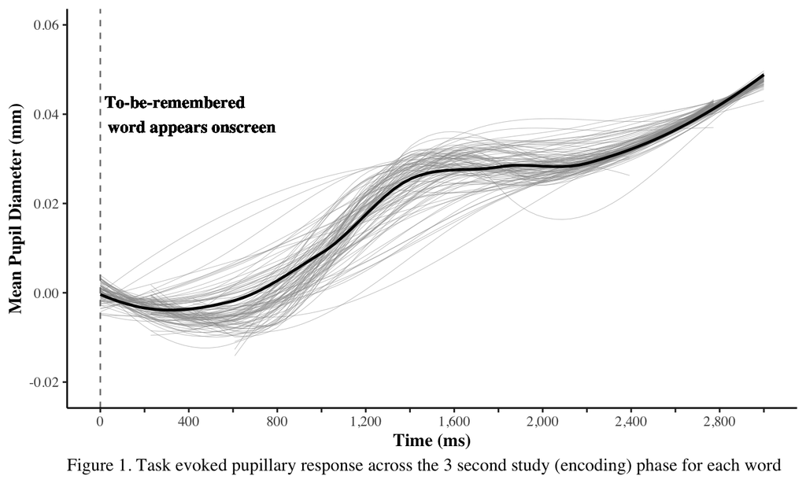

```r
academic_theme <- theme(plot.subtitle = element_text(family = "Times"),
                        plot.caption  = element_text(family = "Times",
                                                     size = 12,
                                                     hjust = 0),
                        axis.title    = element_text(family = "Times",
                                                     face = "bold"),
                        axis.text     = element_text(family = "Times"),
                        axis.text.x   = element_text(family = "Times"),
                        axis.text.y   = element_text(family = "Times"),
                        plot.title    = element_text(family = "Times",
                                                     face = "bold"),
                        legend.text   = element_text(family = "Times"),
                        legend.title  = element_text(family = "Times"),
                        strip.text    = element_text(family = "Times"))

# Apply an academic theme to plot
plot1_academic + academic_theme
```

Here I apply my own theme:

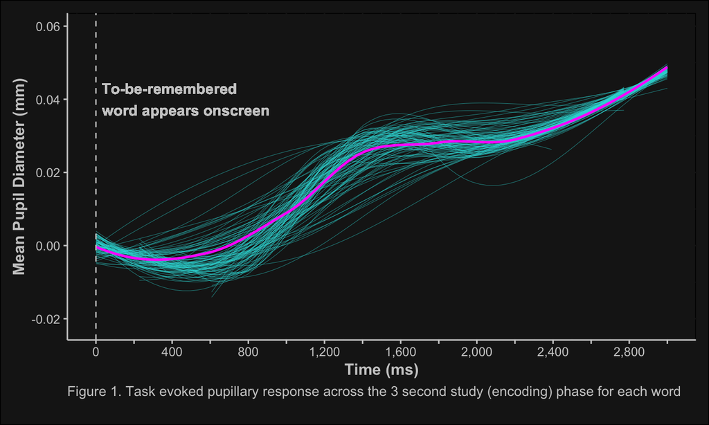

```r
# Plotting both data sources (my data and hypothetical/bootstrapped data)
plot1_fun <- ggplot(plot1, aes(x = bin, y = mean_TEPR)) +
    stat_smooth(aes(group = sample),
              data = d_samps,
              geom = "line",
              color = "#2DDADA",
              fullrange = TRUE,
              size = 0.1) +
    geom_smooth(color = "magenta", se = FALSE, size = 0.9) +
    theme_minimal(base_size = 12) +
    # Change labels
    labs(caption = "Figure 1. Task evoked pupillary response across the 3 second study (encoding) phase for each word",
           y = "Mean Pupil Diameter (mm)",
           x = "Time (ms)") +
    # Relabel x axis values to make more sense to reader
    scale_x_continuous(breaks = c(0, 1, 2, 3, 4, 5, 6, 7, 8,
                                  9, 10, 11, 12, 13, 14, 15),
                       labels = c("0", "", "400", "", "800", "",
                                  "1,200", "", "1,600", "", "2,000",
                                  "", "2,400", "", "2,800", ""),
                       limits = c(0, NA)) +
    # Add text specifying when stimuli appear onscreen
    geom_text(y = 0.04,
              x = 1.6,
              color = "gray80",
              label = "      To-be-remembered
              word appears onscreen", size = 4, fontface = 2) +
    # Add dotted vertical line at x = 0
    geom_vline(aes(xintercept = 0),
               color = "gray80",
               lty = "dashed")

bbg_darktheme <- theme(panel.grid.major = element_line(colour = "gray10"),
                       panel.grid.minor = element_line(colour = "gray10"),
                       axis.text = element_text(colour = "gray80"),
                       axis.text.x = element_text(colour = "gray80"),
                       axis.text.y = element_text(colour = "gray80"),
                       axis.title = element_text(colour = "gray80",
                                                 face = "bold"),
                       axis.ticks = element_line(colour = "gray80"),
                       axis.line = element_line(colour = "gray80"),
                       legend.text = element_text(colour = "gray80"),
                       legend.title = element_text(colour = "gray80"),
                       plot.subtitle = element_text(colour = "gray80"),
                       strip.text = element_text(colour = "gray80",
                                                 face = "bold"),
                       panel.background = element_rect(fill = "gray10"),
                       plot.background = element_rect(fill = "gray10"),
                       legend.background = element_rect(fill = NA,
                                                        color = NA),
                       plot.margin = margin(10, 10, b = 20, 10),
                       plot.caption = element_text(colour = "gray80",
                                                   vjust = 1,
                                                   hjust = 0,
                                                   size = 10.5),
                       plot.title = element_text(colour = "gray80",
                                                 face = "bold"))

plot1_fun + bbg_darktheme
```

### Plot 2

In this section I plot pupil diameter as a function of one’s WMC. See Fig. 5 in [Miller et al. 2019](https://www.sciencedirect.com/science/article/pii/S0749596X18300846) below:

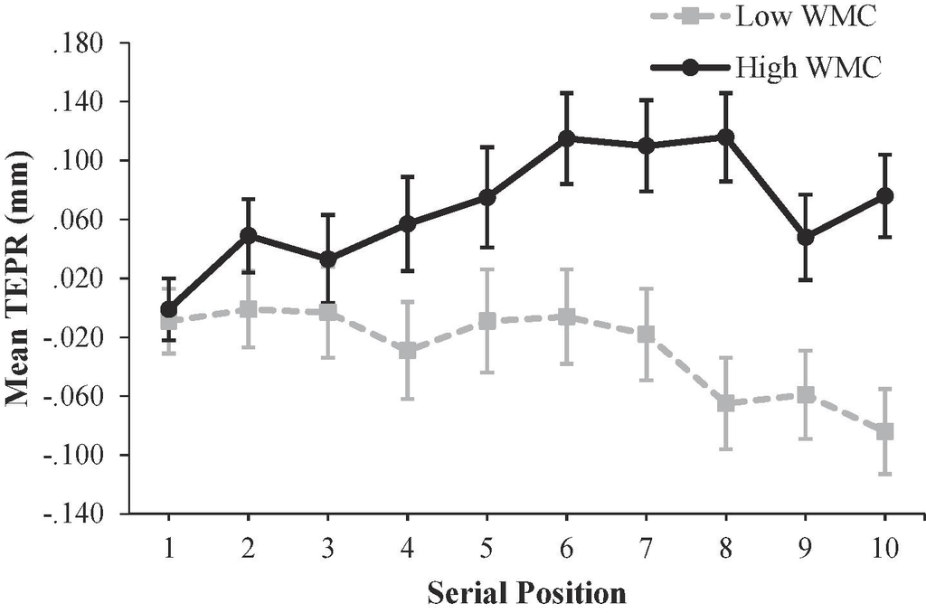

Again, the intended audience for this graph is the **scientific community**. The intended message to be communicated is that different patterns of pupil dilation across serial positions emerge based on one’s working memory capacity (WMC). Namely, for high WMC individuals (*n* = 33), pupil diameter *increases* as each new word is introduced during the learning phase of the task. Alternatively, for low WMC individuals (*n* = 31), pupil diameter *decreases* as each new word is introducted during learning.

Here I re-create this plot but map uncertainty via `geom_ribbon()`:

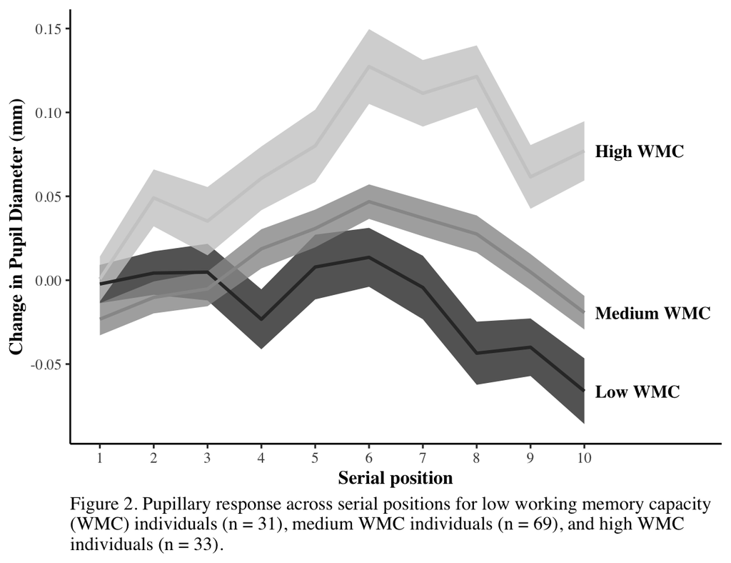

```r
#Reordering factor levels for legend
plot1_data$span_group <- factor(plot1_data$span_group,
                                levels = c("Low", "Medium", "High"))

plot2data <- plot1_data %>%
  group_by(word, span_group) %>%
  summarise(mean_TEPR = mean(TEPR, na.rm = TRUE),
            se_TEPR = sundry::se(TEPR))

# Rename variable for legend
plot2data %<>%
  rename("WMC" = `span_group`)

# Rename variables to enhance clarity
plot2data %<>%
  mutate(WMC = recode(WMC,
                             'Low' = "Low WMC",
                             'Medium' = "Medium WMC",
                             'High' = "High WMC"))

# Plot
plot2_academic <- ggplot(plot2data, aes(x = word, y = mean_TEPR)) +
    geom_ribbon(aes(ymin = mean_TEPR - 1.96*se_TEPR,
                    ymax = mean_TEPR + 1.96*se_TEPR,
                    fill = WMC),
                    alpha = 0.8) +
    scale_fill_grey() +
    # Add reference line for means of each group
    geom_line(aes(colour = WMC), size = 1) +
    scale_colour_grey() +
    # Add labels for each WMC group
    geom_text(data = filter(plot2data, word == '10'),
            aes(y = mean_TEPR, label = WMC),
            color = "black",
            nudge_x = .20,
            hjust = 0,
            size = 4,
            family = "Times",
            fontface = 2) +
    theme_classic(base_size = 12) +
    # Left-align caption
    theme(legend.position = "none") +
    # Change labels
    labs(caption = "Figure 2. Pupillary response across serial positions for low working memory capacity
(WMC) individuals (n = 31), medium WMC individuals (n = 69), and high WMC
individuals (n = 33).",
           y = "Change in Pupil Diameter (mm)",
           x = "Serial position",
           colour = "") +
   # Relabel x axis values to make more sense to reader
   scale_x_continuous(breaks = c(1, 2, 3, 4, 5, 6, 7, 8, 9, 10),
                      labels = c("1", "2", "3", "4", "5",
                                 "6", "7", "8", "9", "10"),
                      limits = c(1, 12))

plot2_academic + academic_theme
```

Now I add some color and apply my own personal theme:

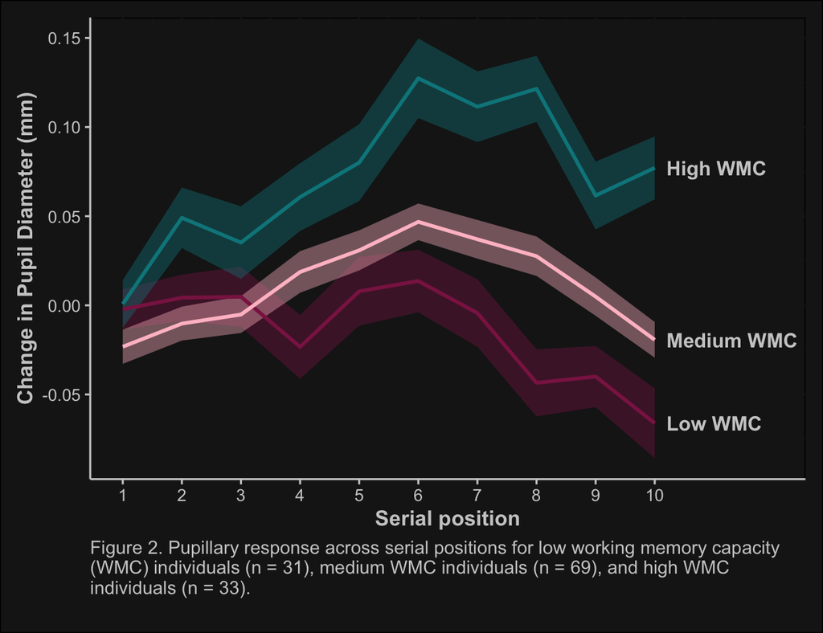

```r
#Specify colors for my own color palette
outrun <- c("violetred4", "pink", "turquoise4")

#Plot
plot2_fun <- ggplot(plot2data, aes(x = word, y = mean_TEPR)) +
    geom_ribbon(aes(ymin = mean_TEPR - 1.96*se_TEPR,
                    ymax = mean_TEPR + 1.96*se_TEPR,
                    fill = WMC),
                    alpha = 0.4) +
    scale_fill_manual(values =  outrun) +
    geom_line(aes(colour = WMC), size = 1) +
    scale_colour_manual(values = outrun) +
    # Add labels for each WMC group
    geom_text(data = filter(plot2data, word == '10'),
            aes(y = mean_TEPR, label = WMC),
            color = "gray80",
            nudge_x = .20,
            hjust = 0,
            size = 4,
            fontface = 2) +
    theme_minimal(base_size = 12) +
    # Left-align caption
    theme(legend.position = "none") +
    # Change labels
    labs(caption = "Figure 2. Pupillary response across serial positions for low working memory capacity
(WMC) individuals (n = 31), medium WMC individuals (n = 69), and high WMC
individuals (n = 33).",
           y = "Change in Pupil Diameter (mm)",
           x = "Serial position",
           colour = "") +
   # Relabel x axis values to make more sense to reader
   scale_x_continuous(breaks = c(1, 2, 3, 4, 5, 6, 7, 8, 9, 10),
                      labels = c("1", "2", "3", "4", "5",
                                 "6", "7", "8", "9", "10"),
                      limits = c(1, 12))

plot2_fun + bbg_darktheme
```

### Plot 4

Here I attempt to plot relation between recall accuracy and strategy type.

- **Identification of the intended audience:** General public
- **The intended message to be communicated:** Strategies that rely on more elaborative mental processes are associated with better memory performance

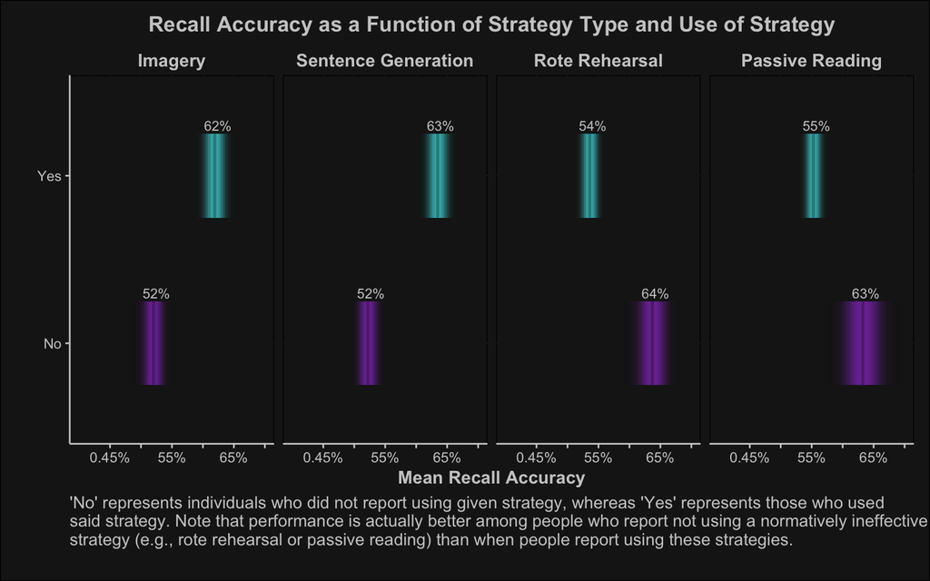

```r
# Select variables of interest
strategy_data <- data %>%
  select(-sp1_acc:-sp10_acc,
         -ospan:-span_group,
         -primacy_recall:-ebin15w10pt4_mean) %>%
  gather(key = strat_type, value = response, passive_read_strat:other_strat)

#levels(as.factor(strategy_data$strat_type))

# Filter out NAs, convert strategy type and score to factors, and recode strat
strategy_data %<>%
  filter(response != "NA") %>%
  mutate(strat_type = as.factor(strat_type),
         response = as.factor(response),
         strat_type = recode(strat_type,
                             "grouping_strat" = "Grouping",
                             "imagery_strat" = "Imagery",
                             "other_strat" = "Other",
                             "passive_read_strat" = "Passive Reading",
                             "rehearsal_strat" = "Rote Rehearsal",
                             "sentence_gen_strat" = "Sentence Generation"))

# Obtain summary stats
strategy_data %<>%
  group_by(strat_type, response) %>%
  summarise(mean_acc = mean(accuracy_mean, na.rm = TRUE),
            se_acc = sundry::se(accuracy_mean))

# Specify factor levels
# Effective strategies = imagery, sentence generation, and grouping
# Ineffective strategies = rehearsal and passive reading
strategy_data$strat_type <- factor(strategy_data$strat_type,
                                levels = c("Imagery",
                                           "Sentence Generation",
                                           "Grouping",
                                           "Rote Rehearsal",
                                           "Passive Reading",
                                           "Other"))

stripe_colors <- c("#7F38A7", "#42B9BD")
bar_colors <- c("#5F2A7C", "#31898C")

plot4 <- strategy_data %>%
  #filter out other and grouping strategy
  filter(strat_type != "Other" & strat_type != "Grouping") %>%
    ggplot(aes(mean_acc, response, group = response, fill = response)) +
        # Add density stripes to mark region of standard error
        stat_confidence_density(aes(moe = se_acc),
                                height = 0.5) +
        scale_fill_manual(values = stripe_colors) +
        # Add vertical line where mean is for each condition
        geom_vpline(aes(colour = response),
                    stat = "summary",
                    size = 0.9) +
        scale_colour_manual(values = bar_colors) +
        # Create seperate sections based on strategy type
        facet_wrap(~strat_type, nrow = 1) +
        # Print accuracy associated with each condition
        geom_text(aes(mean_acc, response, label = paste0(round(mean_acc*100), "%")),
                  nudge_x = 0.005,
                  nudge_y = 0.3,
                  size = 3,
                  color = "gray80") +
        theme_minimal() +
        # Delete legend, increase size of facet labels, and center title
        theme(legend.position = "none",
              strip.text = element_text(size = 11),
              plot.title = element_text(hjust = 0.5)) +
        labs(title = "Recall Accuracy as a Function of Strategy Type and Use of Strategy",
                     y = "",
                     x = "Mean Recall Accuracy",
                     caption = "'No' represents individuals who did not report using given strategy, whereas 'Yes' represents those who used
said strategy. Note that performance is actually better among people who report not using a normatively ineffective
strategy (e.g., rote rehearsal or passive reading) than when people report using these strategies.") +
        # Rename labels on x-axis
        scale_y_discrete(breaks = c(0, 1),
                         labels = c("No", "Yes")) +
        # Modify names/range of y-axis
        scale_x_continuous(breaks = c(0.45, 0.50, 0.55, 0.6, 0.65, 0.70),
                           labels = c("0.45%", "", "55%" , "", "65%", ""),
                           limits = c(0.40, 0.70))

plot4 + bbg_darktheme
```